# Labor Market Analysis

Revised Econometric Model

Marjorie Blanco, Joe Thomson, Haodi Tu

## Research Questions

1. How do earnings vary by education level?
2. How does the premium for education vary by gender?

## Revised Model

```
##
## Call:
## lm(formula = PERNP ~ Widowed + Divorced + Separated + NeverMarried +
##     Female + RaceBlack + RaceOther + SomeCollege + Associate +
##     Bachelor + Master + Professional + Doctoral + AGEP, data = ss16ppr)
##
## Residuals:
##    Min     1Q Median     3Q    Max
## -43683  -9228  -2919   5341  98762
##
## Coefficients:
##              Estimate Std. Error t value             Pr(>|t|)
## (Intercept)  12598.97    1110.28  11.348 < 0.0000000000000002 ***
## Widowed       1104.92    1888.02   0.585             0.558422
## Divorced     -1078.74     571.98  -1.886             0.059353 .
## Separated    -1833.17    1489.22  -1.231             0.218393
## NeverMarried -2974.75     520.48  -5.715        0.00000001155 ***
## Female       -4868.47     432.66 -11.252 < 0.0000000000000002 ***
## RaceBlack    -1178.01     591.36  -1.992             0.046421 *
## RaceOther    -2141.04     579.98  -3.692             0.000225 ***
## SomeCollege   4241.63     694.73   6.105        0.00000000110 ***
## Associate     4150.43     688.45   6.029        0.00000000177 ***
## Bachelor     12337.16     587.07  21.015 < 0.0000000000000002 ***
## Master       17795.40     812.61  21.899 < 0.0000000000000002 ***
## Professional 28133.37    1476.36  19.056 < 0.0000000000000002 ***
## Doctoral     35674.46    1617.08  22.061 < 0.0000000000000002 ***
## AGEP           284.94      21.12  13.488 < 0.0000000000000002 ***
## ---
## Signif. codes:  0 '***' 0.001 '**' 0.01 '*' 0.05 '.' 0.1 ' ' 1
##
## Residual standard error: 14920 on 5179 degrees of freedom
## Multiple R-squared:  0.2466, Adjusted R-squared:  0.2446
## F-statistic: 121.1 on 14 and 5179 DF,  p-value: < 0.00000000000000022
```

### Interpretation

- Coefficients Explanation
- Holding gender, race, education and age constant, married people makes $1104.92 less than people who widowed on average.
- Holding gender, race, education and age constant, married people makes $1078.74 more than people who divorced on average.
- Holding gender, race, education and age constant, married people makes $1833.17 more than people who separated on average.
- Holding gender, race, education and age constant, married people makes $2974.75 more than people who never married on average.
- Holding marriage, race, education and age constant, male makes $4868.47 more than female on average.
- Holding marriage, gender, education and age constant, White makes $1178.01 more than Black on average.
- Holding marriage, gender, education and age constant, White makes $2141.04 more than Other race on average.
- Holding marriage, gender, race and age constant, people have high school education makes $4241.63 less than people have some college education on average.
- Holding marriage, gender, race and age constant, people have high school education makes $4150.43 less than people have associate education on average.
- Holding marriage, gender, race and age constant, people have high school education makes $12337.16 less than people have bachelor’s degree on average.
- Holding marriage, gender, race and age constant, people have high school education makes $17795.4 less than people have master’s degree on average.
- Holding marriage, gender, race and age constant, people have high school education makes $28133.37 less than people have Professional education on average.
- Holding marriage, gender, race and age constant, people have high school education makes $35674.46 less than people have doctor’s degree on average.
- Holding marriage, gender, race and education constant, people make $284.94 more as age increases on average between the age of 18 to 64.

### Model Diagnostics

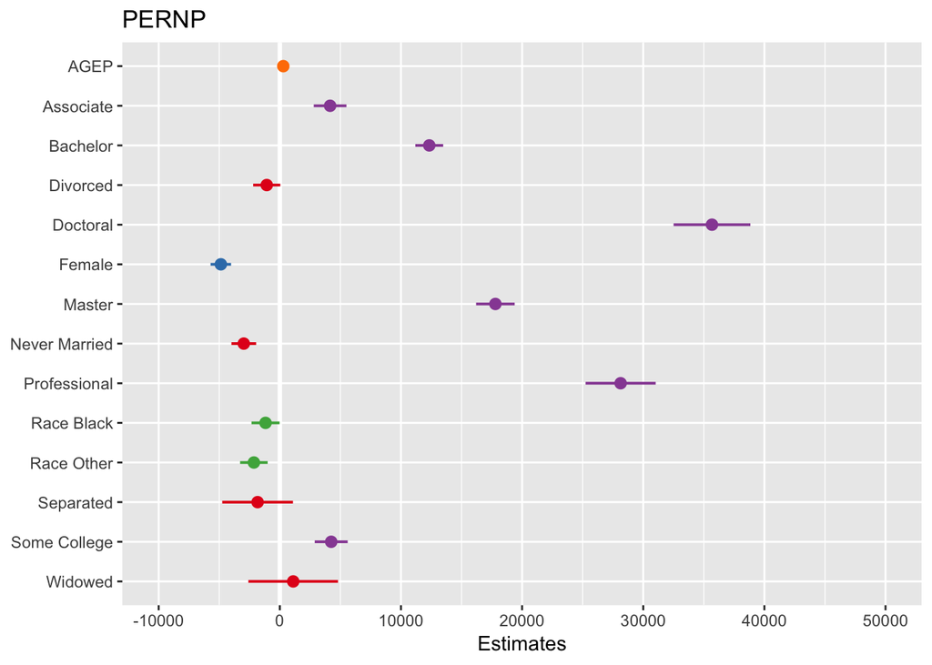

| Variables | Tolerance | VIF |
| --- | --- | --- |
| Widowed | 0.9729050 | 1.027850 |
| Divorced | 0.8808670 | 1.135245 |
| Separated | 0.9756434 | 1.024965 |
| NeverMarried | 0.7702636 | 1.298257 |
| Female | 0.9159123 | 1.091808 |
| RaceBlack | 0.9633247 | 1.038072 |
| RaceOther | 0.9650376 | 1.036229 |
| SomeCollege | 0.6878124 | 1.453885 |
| Associate | 0.6814727 | 1.467410 |
| Bachelor | 0.5604312 | 1.784341 |
| Master | 0.7394234 | 1.352405 |
| Professional | 0.9238792 | 1.082393 |
| Doctoral | 0.9320203 | 1.072938 |
| AGEP | 0.8267426 | 1.209566 |

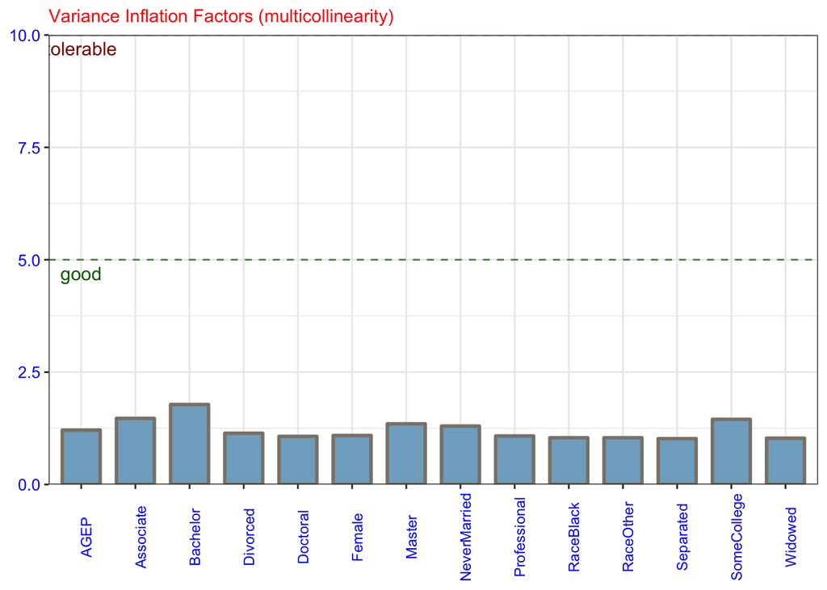

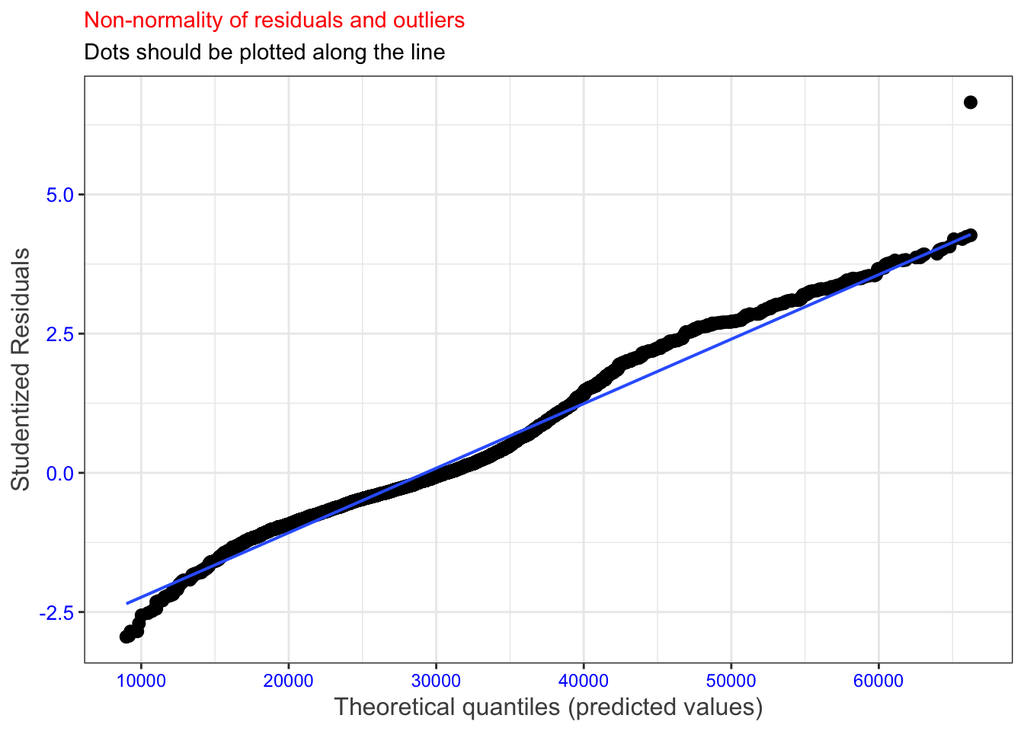

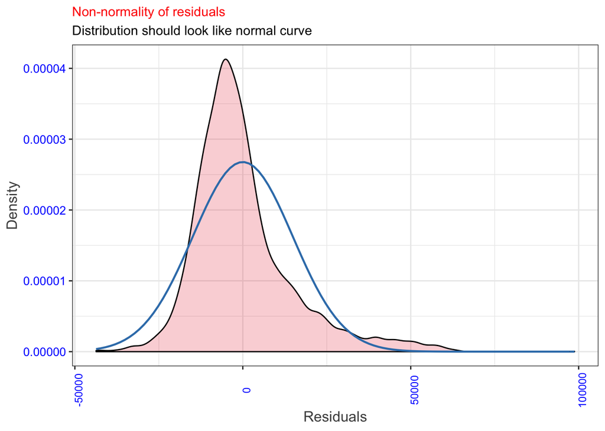

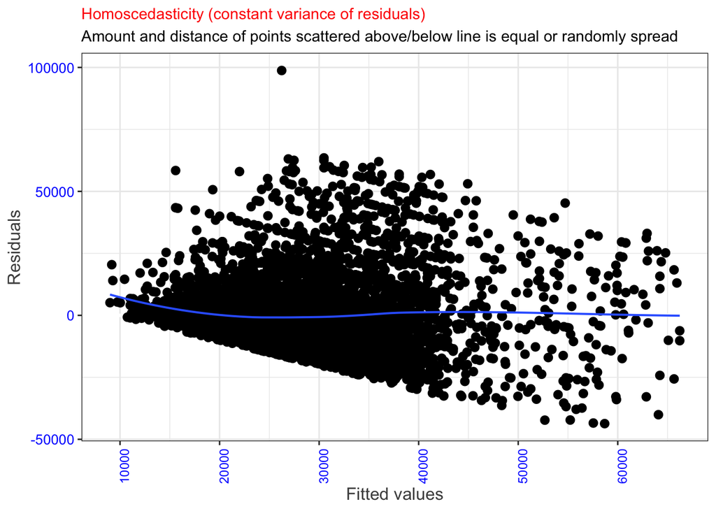

The plot shows heteroscedasticity as the variance of the residuals are not constant.

### Breusch-Pagan test

$H0$: Variance is unchanging in the residual $H1$: Variance is changing in the residual

```
##
##  studentized Breusch-Pagan test
##
## data:  Model_1
## BP = 297.55, df = 14, p-value < 0.00000000000000022
```

The p-Value < 0.05 which indicates that the null hypothesis (the variance is unchanging in the residual) can be rejected and therefore heterscedasticity exists.

### Revised Model wit robust standard errors

```
##
## Call:
## lm(formula = residuals(Model_1) * residuals(Model_1) ~ Widowed +
##     Divorced + Separated + NeverMarried + Female + RaceBlack +
##     RaceOther + SomeCollege + Associate + Bachelor + Master +
##     Professional + Doctoral + AGEP, data = ss16ppr)
##
## Residuals:
##        Min         1Q     Median         3Q        Max
## -620286278 -187332480  -89004449   -6623206 9554893533
##
## Coefficients:
##               Estimate Std. Error t value             Pr(>|t|)
## (Intercept)  -22272288   35096119  -0.635               0.5257
## Widowed       10526294   59680719   0.176               0.8600
## Divorced      -9634464   18080343  -0.533               0.5941
## Separated    -74925738   47074515  -1.592               0.1115
## NeverMarried -41219294   16452372  -2.505               0.0123 *
## Female       -86614125   13676418  -6.333  0.00000000026057555 ***
## RaceBlack    -30492334   18693117  -1.631               0.1029
## RaceOther    -56411117   18333200  -3.077               0.0021 **
## SomeCollege   54139584   21960626   2.465               0.0137 *
## Associate     38592334   21762198   1.773               0.0762 .
## Bachelor     167802881   18557574   9.042 < 0.0000000000000002 ***
## Master       240588080   25686793   9.366 < 0.0000000000000002 ***
## Professional 363259303   46668182   7.784  0.00000000000000843 ***
## Doctoral     283832422   51116425   5.553  0.00000002953675723 ***
## AGEP           4843548     667752   7.254  0.00000000000046605 ***
## ---
## Signif. codes:  0 '***' 0.001 '**' 0.01 '*' 0.05 '.' 0.1 ' ' 1
##
## Residual standard error: 471600000 on 5179 degrees of freedom
## Multiple R-squared:  0.05729,    Adjusted R-squared:  0.05474
## F-statistic: 22.48 on 14 and 5179 DF,  p-value: < 0.00000000000000022
```

[output not shown]

[output cut: 9 more lines]

```
## (Intercept)  -18128.78819
## Widowed       -3587.83358
## Divorced       -293.02429
## Separated     -1156.12421
## NeverMarried   3781.17492
## Female         -787.26885
## RaceBlack       -97.32446
## RaceOther      -420.43504
## SomeCollege    1437.58685
## Associate      1046.66000
## Bachelor        949.82059
## Master          127.40891
## Professional   1732.88105
## Doctoral      -2150.92312
## AGEP            413.64705
```

```
##  (Intercept)      Widowed     Divorced    Separated NeverMarried
##   1003.95869   1998.93756    590.81024   1251.35925    492.08953
##       Female    RaceBlack    RaceOther  SomeCollege    Associate
##    440.50922    561.92633    527.86154    576.27344    564.81504
##     Bachelor       Master Professional     Doctoral         AGEP
##    554.70287    920.55830   2096.28800   2184.05022     20.33831
```

## Revised Logarithmic Model

```
##
## Call:
## lm(formula = log(PERNP, base = exp(1)) ~ Widowed + Divorced +
##     Separated + NeverMarried + Female + RaceBlack + RaceOther +
##     SomeCollege + Associate + Bachelor + Master + Professional +
##     Doctoral + AGEP, data = ss16ppr)
##
## Residuals:
##      Min       1Q   Median       3Q      Max
## -1.56195 -0.30715 -0.03111  0.27690  1.69792
##
## Coefficients:
##                Estimate Std. Error t value             Pr(>|t|)
## (Intercept)   9.5841704  0.0331471 289.140 < 0.0000000000000002 ***
## Widowed       0.0167914  0.0563665   0.298             0.765794
## Divorced     -0.0391735  0.0170763  -2.294             0.021829 *
## Separated    -0.0437489  0.0444603  -0.984             0.325162
## NeverMarried -0.1033310  0.0155387  -6.650   0.0000000000323503 ***
## Female       -0.1380595  0.0129169 -10.688 < 0.0000000000000002 ***
## RaceBlack    -0.0278297  0.0176550  -1.576             0.115017
## RaceOther    -0.0570606  0.0173151  -3.295             0.000989 ***
## SomeCollege   0.1505241  0.0207411   7.257   0.0000000000004534 ***
## Associate     0.1546604  0.0205537   7.525   0.0000000000000619 ***
## Bachelor      0.4214137  0.0175270  24.044 < 0.0000000000000002 ***
## Master        0.5748312  0.0242603  23.694 < 0.0000000000000002 ***
## Professional  0.8187333  0.0440766  18.575 < 0.0000000000000002 ***
## Doctoral      0.9597258  0.0482778  19.879 < 0.0000000000000002 ***
## AGEP          0.0092656  0.0006307  14.692 < 0.0000000000000002 ***
## ---
## Signif. codes:  0 '***' 0.001 '**' 0.01 '*' 0.05 '.' 0.1 ' ' 1
##
## Residual standard error: 0.4454 on 5179 degrees of freedom
## Multiple R-squared:  0.2556, Adjusted R-squared:  0.2536
## F-statistic:   127 on 14 and 5179 DF,  p-value: < 0.00000000000000022
```

### Interpretation

- Coefficients Explanation
- Holding gender, race, education and age constant, married people makes $1.69% less than people who widowed on average.
- Holding gender, race, education and age constant, married people makes $3.84% more than people who divorced on average.
- Holding gender, race, education and age constant, married people makes $4.28% more than people who separated on average.
- Holding gender, race, education and age constant, married people makes $9.82% more than people who never married on average.
- Holding marriage, race, education and age constant, male makes $12.9% more than female on average.
- Holding marriage, gender, education and age constant, White makes $2.74% more than Black on average.
- Holding marriage, gender, education and age constant, White makes $5.55% more than Other race on average.
- Holding marriage, gender, race and age constant, people have high school education makes $16.24% less than people have some college education on average.
- Holding marriage, gender, race and age constant, people have high school education makes $16.73% less than people have associate education on average.
- Holding marriage, gender, race and age constant, people have high school education makes $52.41% less than people have bachelor’s degree on average.
- Holding marriage, gender, race and age constant, people have high school education makes $77.68% less than people have master’s degree on average.
- Holding marriage, gender, race and age constant, people have high school education makes $126.76% less than people have Professional education on average.
- Holding marriage, gender, race and age constant, people have high school education makes $161.1% less than people have doctor’s degree on average.
- Holding marriage, gender, race and education constant, people make $0.93% more as age increases on average between the age of 18 to 64.

### Model Diagnostics

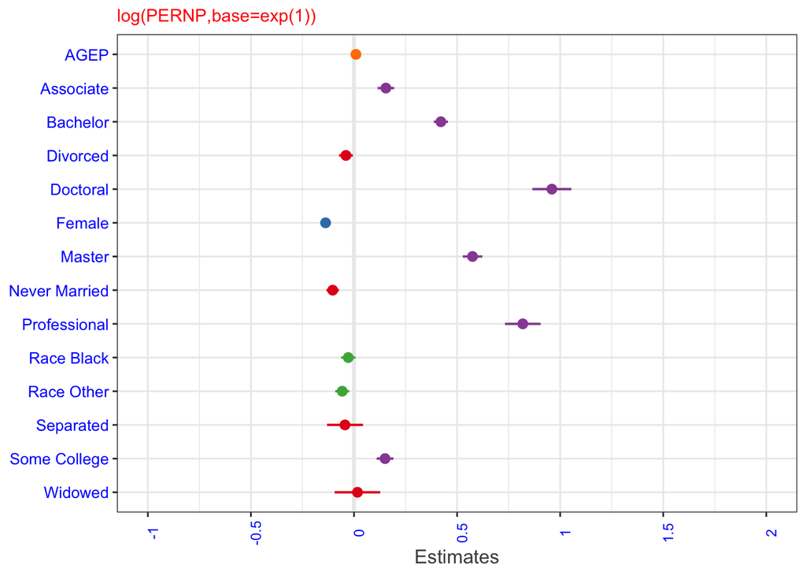

| Variables | Tolerance | VIF |
| --- | --- | --- |
| Widowed | 0.9729050 | 1.027850 |
| Divorced | 0.8808670 | 1.135245 |
| Separated | 0.9756434 | 1.024965 |
| NeverMarried | 0.7702636 | 1.298257 |
| Female | 0.9159123 | 1.091808 |
| RaceBlack | 0.9633247 | 1.038072 |
| RaceOther | 0.9650376 | 1.036229 |
| SomeCollege | 0.6878124 | 1.453885 |
| Associate | 0.6814727 | 1.467410 |
| Bachelor | 0.5604312 | 1.784341 |
| Master | 0.7394234 | 1.352405 |
| Professional | 0.9238792 | 1.082393 |
| Doctoral | 0.9320203 | 1.072938 |
| AGEP | 0.8267426 | 1.209566 |

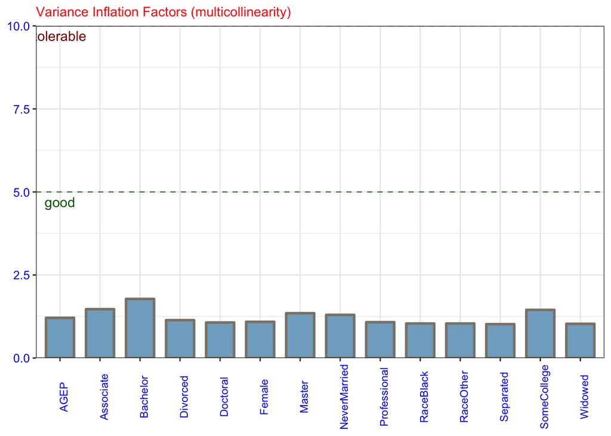

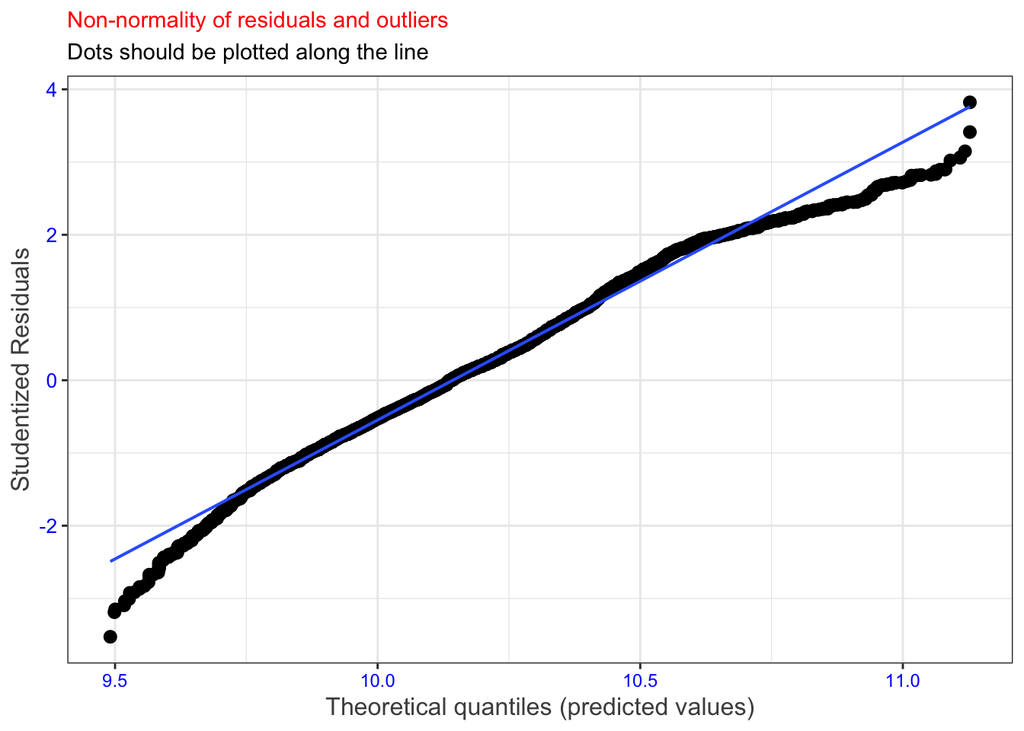

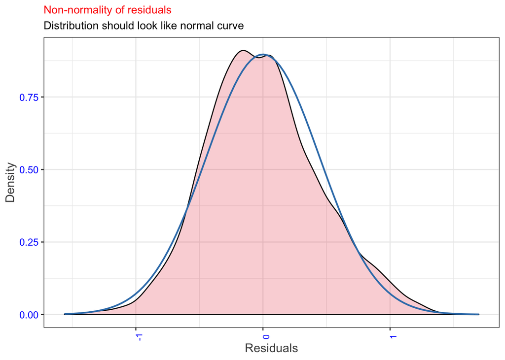

The plot shows that the distribution of the residuals are approximately normally distributed.

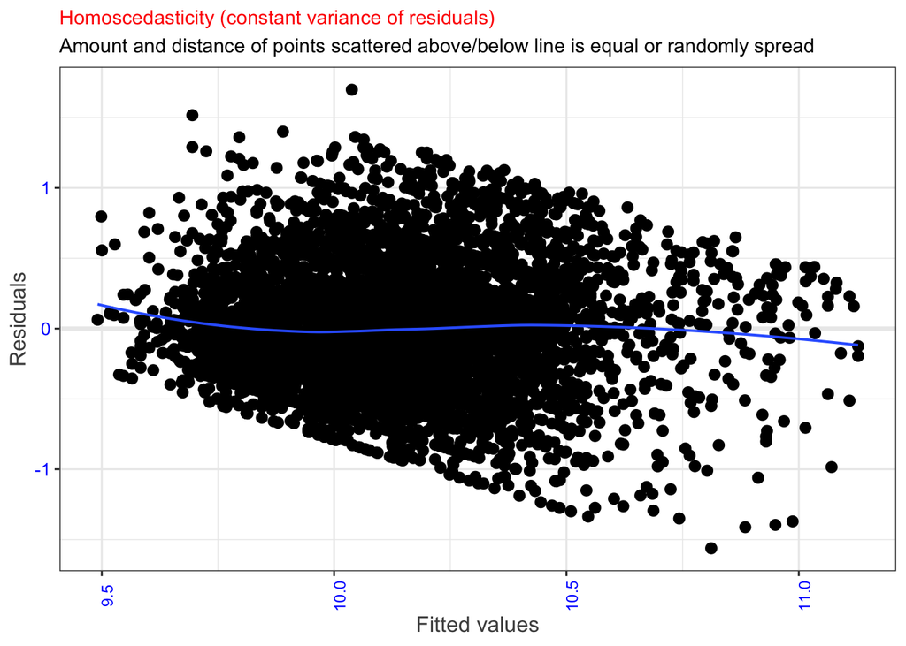

The plot shows heteroscedasticity as the variance of the residuals are not constant.